# Ch6: Linear Model Selection and Regularization

Philip Lin

2014.12.17

# Outline

- Two perspectives in model selection
- Model selection criterions
  - Mellow’s Cp
  - Akaike information criterion (AIC)
  - Bayesian Information Criterion (BIC)
- Classical selection approach
  - Best subset selection
  - Foreward, backward and stepwise
- Regularization
  - From LSE to Ridge
    - Decorrelation
    - Prediction performance
  - From Ridge to Lasso
    - Sparsity
    - Solution path of Lasso
    - Bias of estimates in Ridge and Lasso
    - Why Lasso is so popular ?

# Two perspectives in model selection

- **consistent**: A consistent criterion identifies the true model with a probability that approaches 1 in large samples when a set of candidate models contains the true model – Zhang, Li and Tsai (2010)
  - foucs on explanation and only select important factors that affect your response.
  - e.g.: fMRI, genetics, …
- **efficient**: An efficient criterion selects the model so that its average squared error is asymptotically equivalent to the minimum offered by the candidate models when the true model is approximated by a family of candidate models. – Zhang, Li and Tsai (2010)
  - focus on the performance of prediction on future data, can tolerant slightly overfitted model.
  - e.g.: Online advertisement (to predict the individual behavior)
- What did you see in these two paragraph ?
  - In the view of cosistency, we assume the true model is in our candidates.
  - In the view of efficiency, we assume one of our candidates get closed to the truth.
  - Two optimal criterion are described in the words of “asymptotic” and “probability”

# Model selection criterions: Cp

$y = X\beta + \epsilon = \mu + \epsilon$ $\begin{align*} \{(x_1,y_1),\dots,(x_n,y_n)\} \overset{i.i.d.}{\sim} F \end{align*}$ $\begin{align*} \sum(y_i-\hat{\mu}_i)^2 &= \sum(y_i-\mu_i+\mu_i-\hat{\mu}_i)^2 \\ &=\sum(y_i-\mu_i)^2 + \sum(\mu_i-\hat{\mu}_i)^2 - 2\sum(y_i-\mu_i)(\hat{\mu}_i-\mu_i)\\ \sum(y_i-\mu_i)^2 + \sum(\mu_i-\hat{\mu}_i)^2 &= \sum(y_i-\hat{\mu}_i)^2 + 2\sum(y_i-\mu_i)(\hat{\mu}_i-\mu_i)\\ &= \sum(y_i-\hat{\mu}_i)^2 + 2\sigma^2 p \end{align*}$

If we are interested in $\sum(\mu_i-\hat{\mu}_i)^2$ $E[\sum(\mu_i-\hat{\mu}_i)^2] = E[\sum(y_i-\hat{\mu}_i)^2] - n\sigma^2+2\sigma^2 p$ Take unbiased estimator of $\sum(\mu_i-\hat{\mu}_i)^2/\sigma^2$ $C_p = \frac{\|y-\hat{\mu}\|^2}{\sigma^2} -n+2p$

# Model selection criterions: AIC

$y = X\beta + \epsilon = \mu + \epsilon$ $\begin{align*} \{(x_1,y_1),\dots,(x_n,y_n)\} \overset{i.i.d.}{\sim} F \end{align*}$ $\begin{align*} \sum(y_i-\hat{\mu}_i)^2 &= \sum(y_i-\mu_i+\mu_i-\hat{\mu}_i)^2 \\ &=\sum(y_i-\mu_i)^2 + \sum(\mu_i-\hat{\mu}_i)^2 - 2\sum(y_i-\mu_i)(\hat{\mu}_i-\mu_i)\\ \sum(y_i-\mu_i)^2 + \sum(\mu_i-\hat{\mu}_i)^2 &= \sum(y_i-\hat{\mu}_i)^2 + 2\sum(y_i-\mu_i)(\hat{\mu}_i-\mu_i)\\ &= \sum(y_i-\hat{\mu}_i)^2 + 2\sigma^2 p \end{align*}$

If we are interested in $\sum(y_i^0-\hat{\mu}_i)^2$, by independence we have $E_0[\sum(y_i^0-\mu_i)^2] = E[\sum(y_i-\mu_i)^2]$

$\begin{align*} \sum(y_i-\mu_i) + \sum(\mu_i-\hat{\mu}_i)^2 &= \sum(y_i-\hat{\mu}_i)^2 + 2\sum(y_i-\mu_i)(\hat{\mu}_i-\mu_i)\\ E[\sum(y_i^0-\mu_i+\mu_i-\hat{\mu}_i)^2] &= E[\sum(y_i-\hat{\mu}_i)^2] + 2\sigma^2 p\\ E[\sum(y_i^0-\hat{\mu}_i)^2] &= E[\sum(y_i-\hat{\mu}_i)^2] + 2\sigma^2 p \end{align*}$

Take unbiased estimator of $\sum(y_i^0-\hat{\mu}_i)^2$

$\text{AIC}(\hat{\mu}) = \|y-\hat{\mu}\|^2 + 2\sigma^2 p$

- Remarks
  - AIC is an unbiased estimator of testing MSE and is based on the same spirit of Cross Validation.
  - Actually, AIC and CV are asymptotic equivalent in the linear model scheme.

# Model selection criterions: BIC

$y = X\beta + \epsilon$

- Suppose
  - $s$ be a subset of $\{1,2,\dots,p\}$. That is, $s$ is a model index.
  - $p(s)$ be the prior of the model $s$

Then, in the view of Bayesian

$\begin{align*} p(s|y) =& \frac{p(y|s)p(s)}{p(y)} \propto p(y|s)p(s) \\ =& p(y|s) ~~~ \text{assume each model with equal prior} \\ =& \int \frac{p(y|s,\beta)p(\beta|s)p(s)}{p(s)} \text{d}\beta \\ =& \cdots \end{align*}$

By maximizing the posterior probability $p(s|y)$ with the help of Laplace approximation, we obtain

$\text{BIC}(\hat{\mu}) = \|y-\hat{\mu}\|^2 + \log n \cdot \sigma^2 |s|$

# Model selection criterions: BIC

- Remarks
  - Comparing these three different criterions, they all put an penalty on training MSE, which under estimate the testing error rate. Thus, these three criterions can be seen as an approach that adjust the training error to estimate testing error.
  - BIC is based on maximizing the posterior probability of each candidate model without consideration of prediction error.
  - In the literature, with **some regular conditions**, BIC attains selection consistency.
    - Note that BIC assume equal prior for each candidate, which makes it become poor in high dimensional case.
    - Note again that the Laplace approximation will not approximate well when covariates are highly correlated, which happens frequently in high dimensional case.
  - Compared to AIC, which attains nearly optimal in minimizing prediction error but prefer a slightly overfitted model, BIC select important covariates only.
  - Properties in AIC and properties in BIC cannot be shared theoretically. i.e., Selection consistency and minimizing prediction error will not happen at the same time.

# Classical selection approach

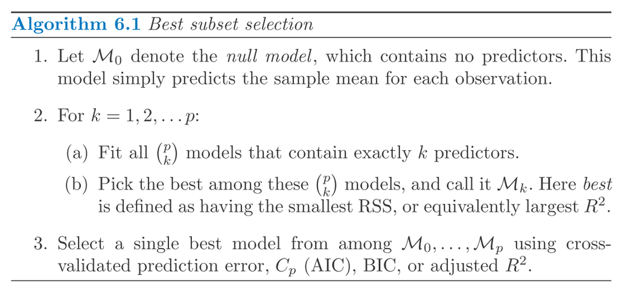

- When $p=20$, there are $2^{20}=1048576$ candidates.
- The larger search space, the higher the chance of finding models that look good on the training, even though they might not have any predictive power on future data.

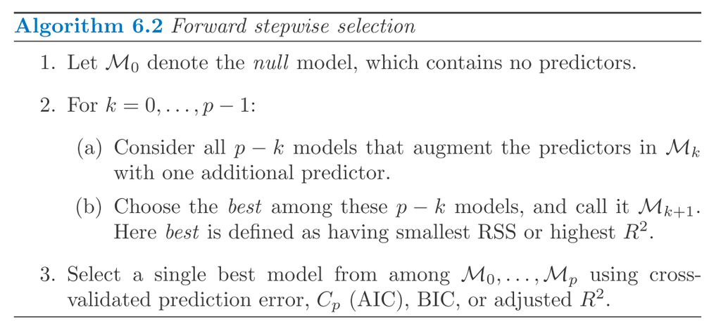

# Questions

Till now, we can ask ourself some questions:

1. The logic of model selection can be described as two steps:
   - Construct a set of candidate models
   - Choose the best model in your candidates
2. Should we insist on searching whole possible candidate models (like best subset) ?
3. Is there an efficient way to construct a small but useful set of candidates ?

# From LSE to Ridge

For $n$ observations with $p$ covariates $y = X\beta + \epsilon$

- Least Square Estimator $\hat{\beta}_{LSE} = (X^TX)^{-1}X^Ty$
  - solution exist only when $p < n$
  - as $p$ gets larger, or gets closer to $n$ from below, overfitted problem potentially exist.

# From LSE to Ridge

- Before doing any regularization method, $X$ should be standardized first $\sum_{i=1}^ny_i=0, \sum_{i=1}^n x_{ij}=0, \sum_{i=1}^n x^2_{ij}=1, j=1,\dots,p$
- Ridge regression $\hat{\beta}_{R} = (X^TX + \lambda I)^{-1}X^Ty$ where $\lambda >0$
  - solution always exist even for $n < p$
  - tuning parameter $\lambda$ provides decorrelation effect  
    $\hat{\Sigma}_R^{-1}=(X^TX+\lambda I)^{-1}=\frac{1}{1+\lambda} \left( \begin{array}{cccc} 1 & \frac{\rho_{12}}{1+\lambda} & . & \frac{\rho_{1p}}{1+\lambda} \\ & 1 & . & . \\ & & 1 & \frac{\rho_{p-1,p}}{1+\lambda}\\ & & & 1 \end{array} \right)^{-1}$  
    when $\lambda$ get larger, the correlation become smaller.

# Prediction performance of Ridge

- Testing error of Ridge

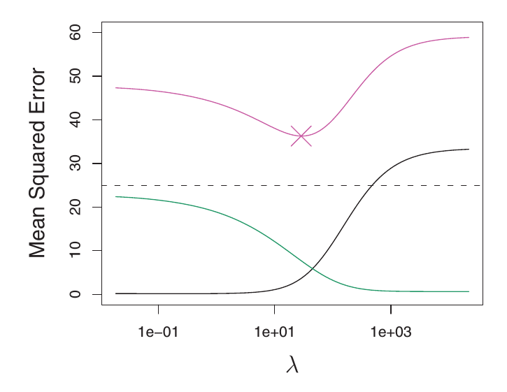

```
- green: vairance
- black: squared bias
- purple: test MSE
```

$\begin{align*} E(y_0-\hat{f}(x_0))^2 =& E[\hat{f}(x_0) - E\hat{f}(x_0) + E\hat{f}(x_0) - f(x_0) - y_0 + f(x_0)]^2 \\ =& E[\hat{f}(x_0)-E\hat{f}(x_0)]^2 + E(E\hat{f}(x_0)-f(x_0))^2 + E(y_0-f(x_0))^2 \\ =& \text{var}(\hat{f}(x_0)) + [\text{Bias}(\hat{f}(x_0))]^2 + \sigma^2 \end{align*}$

# Solution path of Ridge

- Solution path

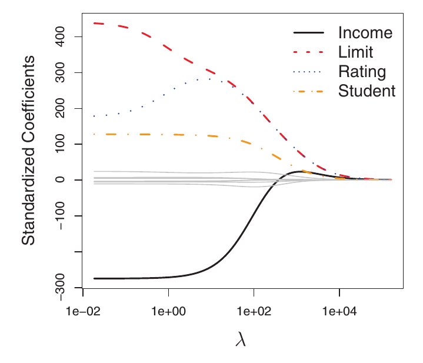

- Ridge shrinks all coefficients to zero as $\lambda$ increase, but not exactly zero.
- Regularization approach produce a very good solution path. (cf: best subset, foreward, …)

# From Ridge to Lasso

There is another formulation for ridge $\hat{\beta}_R = \arg\min_{\beta} \|y-X\beta\|^2 + \lambda\|\beta\|_2^2$

- To obtain the sparsity, replace $l_2$ norm by $l_1$ such that **the objective function is singular at zero**
- we call this optimization LASSO (Least Absolute Shrinkage and Selection Operator)

$\hat{\beta}_L = \arg\min_{\beta} \|y-X\beta\|^2 + \lambda\|\beta\|_1$

Why a penalty which is singular at zero will attin sparsity ?

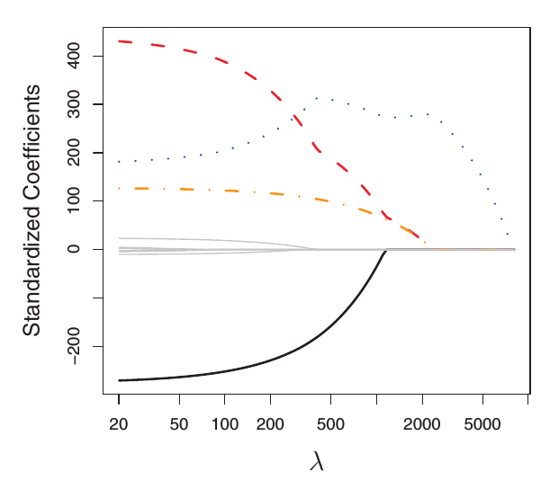

# Explanation of sparsity: dual

Now, we consider only one covariate in LM

$\begin{align*} f(\beta)=&\frac{1}{2}\sum(y_i-\beta x_i)^2 + \lambda|\beta| \\ f'(\beta)=&\sum x_iy_i - \beta + \lambda\text{sgn}(\beta) \end{align*}$

We aims to find a $\beta$ such that $f'(\beta)=0$ (MLE)

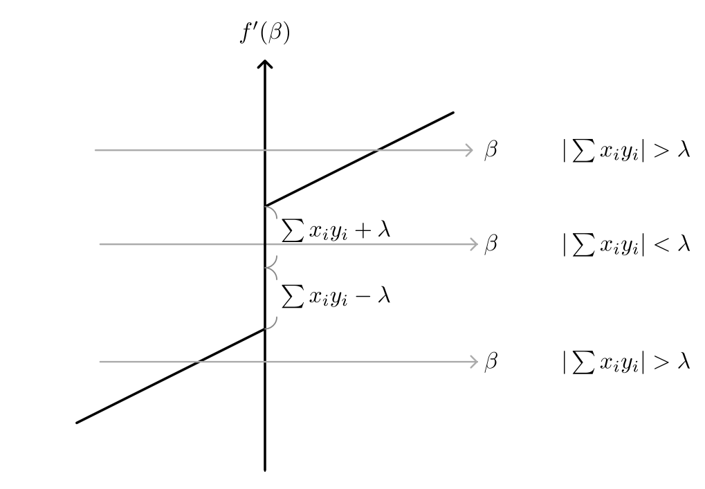

# Explanation of sparsity: primal

Another explanation: by Lagrangian, optimal problem can be translated between primal and dual when the objective function is convex (or concave).

$\begin{align*} \hat{\beta}_R =& \arg\min_{\beta} \|y-X\beta\|^2 + \lambda\|\beta\|_2^2 \\ =& \arg\min_{\beta} \|y-X\beta\|^2 ~~\text{ s.t. }~~ \sum_{j=1}^p\beta_j^2\leq s\\ \hat{\beta}_L =& \arg\min_{\beta} \|y-X\beta\|^2 + \lambda\|\beta\|_1 \\ =& \arg\min_{\beta} \|y-X\beta\|^2 ~~\text{ s.t. }~~ \sum_{j=1}^p|\beta_j|\leq s\\ \end{align*}$

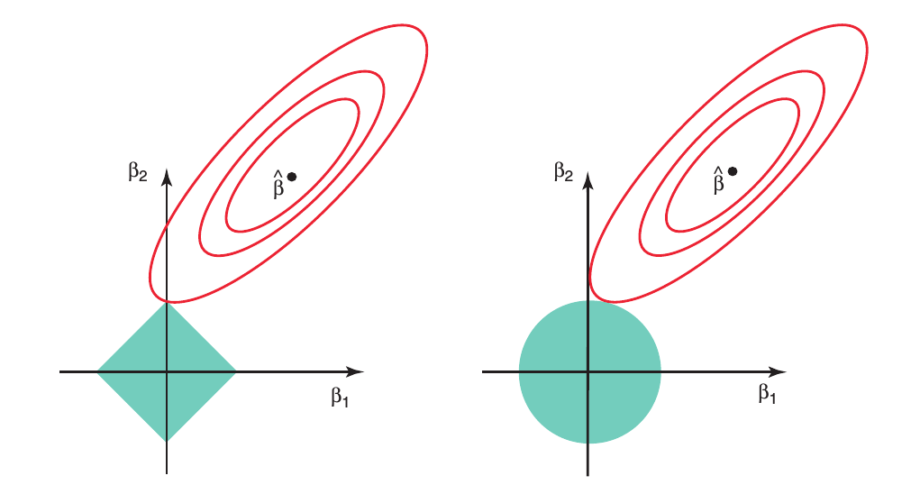

# Bias of estimates in Ridge and Lasso

To simply the notation, we consider a very special case

- $n=p$ and $X$ is an identity matrix
- In this case, MLE is given by $\hat{\beta}_j=y_i$

$\begin{align*} \hat{\beta}_R =& \arg\min_{\beta} \|y-\beta\|^2 + \lambda\sum_{j=1}^p\beta_j^2 \\ \hat{\beta}_L =& \arg\min_{\beta} \|y-\beta\|^2 + \lambda\sum_{j=1}^p|\beta_j| \end{align*}$

for $j$ th estimate

$\begin{align*} \hat{\beta}_j^R =& y_i/(1+\lambda) \\ \hat{\beta}_j^L =& \left\{\begin{array}{ccc} y_j-\lambda/2 & \text{ if } & y_j>\lambda/2 \\ y_j+\lambda/2 & \text{ if } & y_j<-\lambda/2 \\ 0 & \text{ if } & |y_j|<\lambda/2 \\ \end{array}\right. \end{align*}$

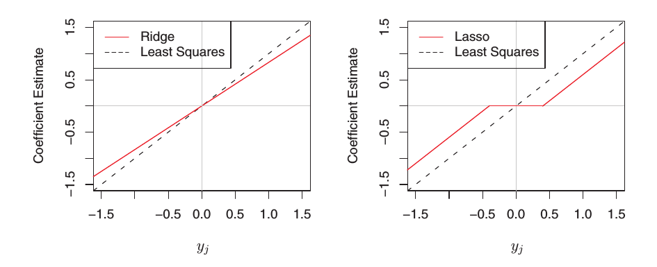

# Some remarks

- Comparison of Ridge and Lasso
  - In the view of testing MSE, no one can beat each other in all cases.
  - Both Ridge and Lasso lead to biased coefficient estimator.
- Solution path
  - By controling the tuning parameter $\lambda$ (from $0$ to $\infty$), we can generate a solution path. However, although this path does not go through all combinations, it is a reasonable one since the shrinkage effect on the near zero estimates.
  - In the regularization world, selecting model is equivalent to selecting an adequate value of penalty $\lambda$.
  - Usually, we can cut $100$ points in interval $\lambda\in[0, a]$ and find the $\lambda$ that correspond to minimum AIC, BIC or CV error. Note that the value of $a$ depends on the real data.
  - Note that the solution path is continuous, which is one of the most critical reasons for attaining better performance in prediction.

# Why Lasso is so popular

- Rate consistency, with **some conditions**
  1. Important covariates has high probability to be included and number of redundant will not be too much.
  2. Covariate estimates of unimportant covariates is guaranteed to be small.
  3. Training error is guaranteed to be small.
- Although Lasso estimates is biased and has been proved that it is **almost** impossible to obtain the selection consistency, the Rate consistency makes it charming.
- The computation algorithm of Lasso is well developed (LARS, Pathwise Coordinate Descent), and many new proposed methods can easily be translated to lasso problem.

# What are we going to do ?

$y = f(X) + \epsilon$

- Unsupervised learning
  - Unsupervised Learning (Ch10)
- Supervised learning (Inference purpose)
  - Linear regression (Ch3)
  - Classification (Ch4)
  - Resampling method (Ch5)
  - Linear model selection and regularization (Ch6)
  - Moving beyond linearity (Ch7)
- Supervised learning (Prediction purpose)
  - Tree based method (Ch8)
  - Support Vector Machine (Ch9)